# Predicting Need for Phototherapy in the Neonatal ICU

Jack McDonnell

2018-05-07

## 0.1 Preliminaries

```r
library(skimr)
library(rmdformats)
library(tableone)
library(leaps)
library(ROCR)
library(rms)
library(broom)
library(tidyverse)

skim_with(numeric = list(hist = NULL),
          integer = list(hist = NULL))
```

# 1 Background

Babies commonly develop jaundice, the colloquial term for a condition due to elevated levels of bilirubin in the blood (hyperbilirubinemia). For many babies, hyperbilirubinemia is a issue that requires serial monitoring rather than treatment. In more severe cases, however, the bilirubin levels need treatment to come down. The mainstay of treatment is a therapy called “phototherapy,” which works by isomerizing the bilirubin to a form that can be excreted through the skin. In the rarest of cases, phototherapy fails and the the patient requires an exchange transfusion to avoid the serious consequences of bilirubin encephalopathy.

In the pediatric literature, several factors have have been linked to increased risk of hyperbilirubinemia. These include prematurity, hemolytic disease of the newborn, G6PD deficiency, asphyxia, lethargy, temperature instability, sepsis, acidosis, hypoalbuminemia, and Asian race. Absent from this of known contributing factors is *birth weight*. Holding other known contributors constant, does birth weight affect the development of clinical jaundice severe enough to require phototherapy?

# 2 Research Questions

My primary research question is simple: **can birth weight be used to predict need for phototherapy in the NICU, adjusting for other relevant covariates?** From this simple question I hope to fit 3 clinically useful models:

1. `m0` - a model predicting need for phototherapy based on information readily available to the clinician in the first few hours of an infant’s life (**delivery room** model)
2. `m1` - a model predicting need for phototherapy based on information readily available to the clinician in the first few days of an infant’s life, but prior to onset of clinical jaundice
3. `m2` - a model predicting need for phototherapy once a baby in the NICU is diagnosed with jaundice

My project is relevant because it arms clinicians with a useful framework to predict need for phototherapy for babies at various clinical stages, based on the information typically available at that particular stage.

# 3 My Data

These data are from the MIMIC-III database (https://mimic.physionet.org). MIMIC contains data from the ICUs (both adult and neonatal) at Beth Israel Deaconess Medical Center from 2001-2012. It is a freely accessible critical care database useful for performing these kinds of analyses.

## 3.1 Data Load

```r
photo_babies <- read.csv("jaundice_final.csv") %>% tbl_df
```

As originally loaded, the `photo_babies` data contain 7246 rows and 69 columns.

## 3.2 Tidying, Data Cleaning and Data Management

With this first section of code, I create a variable for Asian heritage, which is known to be a risk factor for jaundice. Although it is usually not beneficial to collapse more diverse data into binary categories, here it only matters clinically if an infant is Asian or not (as no other ethnic background has been linked to problems with jaundice).

```r
# create a factor variable for ethnicity. Asian heritage is an important risk factor for jaundice
photo_babies_tidy <- photo_babies %>%
    mutate(ethnicity_fac = as.factor(ethnicity))
photo_babies_tidy <- photo_babies_tidy %>%
    mutate(ethnicity_fac = fct_recode(ethnicity_fac,
                                "Other" = "AMERICAN INDIAN/ALASKA NATIVE",
                                "Asian" = "ASIAN",
                                "Asian" = "ASIAN - ASIAN INDIAN",
                                "Asian" = "ASIAN - CHINESE",
                                "Asian" = "ASIAN - FILIPINO",
                                "Asian" = "ASIAN - JAPANESE",
                                "Asian" = "ASIAN - KOREAN",
                                "Asian" = "ASIAN - OTHER",
                                "Asian" = "ASIAN - VIETNAMESE",
                                "Other" = "BLACK/AFRICAN",
                                "Other" = "BLACK/AFRICAN AMERICAN",
                                "Other" = "BLACK/CAPE VERDEAN",
                                "Other" = "BLACK/HAITIAN",
                                "Other" = "HISPANIC OR LATINO",
                                "Other" = "HISPANIC/LATINO - CENTRAL AMERICAN (OTHER)",
                                "Other" = "HISPANIC/LATINO - DOMINICAN",
                                "Other" = "HISPANIC/LATINO - GUATEMALAN",
                                "Other" = "HISPANIC/LATINO - MEXICAN",
                                "Other" = "HISPANIC/LATINO - PUERTO RICAN",
                                "Other" = "HISPANIC/LATINO - SALVADORAN",
                                "Other" = "SOUTH AMERICAN",
                                "Other" = "WHITE - OTHER EUROPEAN",
                                "Other" = "WHITE - EASTERN EUROPEAN",
                                "Other" = "WHITE - BRAZILIAN",
                                "Other" = "WHITE",
                                "Other" = "MIDDLE EASTERN",
                                "Other" = "MULTI RACE ETHNICITY",
                                "Other" = "NATIVE HAWAIIAN OR OTHER PACIFIC ISLANDER",
                                "Other" = "OTHER",
                                "Other" = "PATIENT DECLINED TO ANSWER",
                                "Other" = "PORTUGUESE",
                                "Other" = "UNABLE TO OBTAIN",
                                "Other" = "UNKNOWN/NOT SPECIFIED"))
```

With this section of code, I generate a factor variable for birth weight categories.

```r
# generate birth weight categories
photo_babies_tidy <- photo_babies_tidy %>%
    mutate(birth_weight_fac = as.factor(birth_weight_fac))
photo_babies_tidy <- photo_babies_tidy %>%
                mutate(birth_weight_fac = fct_recode(birth_weight_fac,
                                "Extremely Low Birth Weight (ELBW)" = "ELBW",
                                "Very Low Birth Weight (VLBW)" = "VLBW",
                                "Low Birth Weight (LBW)" = "LBW",
                                "Normal Birth Weight" = "0"))
photo_babies_tidy$birth_weight_fac <- fct_relevel(photo_babies_tidy$birth_weight_fac, "Normal Birth Weight", "Low Birth Weight (LBW)", "Very Low Birth Weight (VLBW)", "Extremely Low Birth Weight (ELBW)")
```

Below I create a factor variable for degree of prematurity. Preterm infants are known to be at increased risk for jaundice.

```r
# track babies by gestational age/degree of prematurity
photo_babies_tidy <- photo_babies_tidy %>%
    mutate(gestational_age_fac = as.factor(gestational_age))
photo_babies_tidy <- photo_babies_tidy %>%
                mutate(gestational_age_fac = fct_recode(gestational_age_fac,
                                "24 weeks and under" = "<= 24 weeks",
                                "25-26 weeks" = "25-26 weeks",
                                "27-28 weeks" = "27-28 weeks",
                                "29-30 weeks" = "29-30 weeks",
                                "31-32 weeks" = "31-32 weeks",
                                "33-34 weeks" = "33-34 weeks",
                                "35-36 weeks" = "35-36 weeks",
                                "term" = "term",
                                NULL = "0"))
```

Here I change a number of variables in the data set into factor variables that R will recognize.

```r
#jaundice risk factors
photo_babies_tidy <- photo_babies_tidy %>%
    mutate(phototherapy = as.factor(phototherapy))
photo_babies_tidy <- photo_babies_tidy %>%
    mutate(died = as.factor(died))
photo_babies_tidy <- photo_babies_tidy %>%
    mutate(HIE = as.factor(HIE))
photo_babies_tidy <- photo_babies_tidy %>%
    mutate(jaundice = as.factor(jaundice))
photo_babies_tidy <- photo_babies_tidy %>%
    mutate(acidosis = as.factor(acidosis))
photo_babies_tidy <- photo_babies_tidy %>%
    mutate(sepsis = as.factor(sepsis))
photo_babies_tidy <- photo_babies_tidy %>%
    mutate(ABO = as.factor(ABO))
photo_babies_tidy <- photo_babies_tidy %>%
    mutate(coombs = as.factor(coombs))
photo_babies_tidy <- photo_babies_tidy %>%
    mutate(hemolytic = as.factor(hemolytic))
photo_babies_tidy <- photo_babies_tidy %>%
    mutate(bruising = as.factor(bruising))
photo_babies_tidy <- photo_babies_tidy %>%
    mutate(crigler = as.factor(crigler))
photo_babies_tidy <- photo_babies_tidy %>%
    mutate(physiologic = as.factor(physiologic))
photo_babies_tidy <- photo_babies_tidy %>%
    mutate(G6PD = as.factor(G6PD))
photo_babies_tidy <- photo_babies_tidy %>%
    mutate(galactosemia = as.factor(galactosemia))
photo_babies_tidy <- photo_babies_tidy %>%
    mutate(gilbert = as.factor(gilbert))
photo_babies_tidy <- photo_babies_tidy %>%
    mutate(delayed_conjugation = as.factor(delayed_conjugation))
photo_babies_tidy <- photo_babies_tidy %>%
    mutate(exchange = as.factor(exchange))

#birth weight
photo_babies_tidy <- photo_babies_tidy %>%
    mutate(bw_1000_1249 = as.factor(bw_1000_1249))
photo_babies_tidy <- photo_babies_tidy %>%
    mutate(bw_1250_1499 = as.factor(bw_1250_1499))
photo_babies_tidy <- photo_babies_tidy %>%
    mutate(bw_1500_1749 = as.factor(bw_1500_1749))
photo_babies_tidy <- photo_babies_tidy %>%
    mutate(bw_1500_1999 = as.factor(bw_1500_1999))
photo_babies_tidy <- photo_babies_tidy %>%
    mutate(bw_1750_1999 = as.factor(bw_1750_1999))
photo_babies_tidy <- photo_babies_tidy %>%
    mutate(bw_2000_2499 = as.factor(bw_2000_2499))
photo_babies_tidy <- photo_babies_tidy %>%
    mutate(bw_2500_up = as.factor(bw_2500_up))
photo_babies_tidy <- photo_babies_tidy %>%
    mutate(bw_500_750 = as.factor(bw_500_750))
photo_babies_tidy <- photo_babies_tidy %>%
    mutate(bw_500_999 = as.factor(bw_500_999))
photo_babies_tidy <- photo_babies_tidy %>%
    mutate(bw_750_999 = as.factor(bw_750_999))
photo_babies_tidy <- photo_babies_tidy %>%
    mutate(bw_under_500 = as.factor(bw_under_500))
photo_babies_tidy <- photo_babies_tidy %>%
    mutate(ELBW = as.factor(ELBW))
photo_babies_tidy <- photo_babies_tidy %>%
    mutate(LBW = as.factor(LBW))
photo_babies_tidy <- photo_babies_tidy %>%
  mutate(VLBW = as.factor(VLBW))

#prematurity
photo_babies_tidy <- photo_babies_tidy %>%
    mutate(preterm24 = as.factor(preterm24))
photo_babies_tidy <- photo_babies_tidy %>%
    mutate(preterm25_26 = as.factor(preterm25_26))
photo_babies_tidy <- photo_babies_tidy %>%
    mutate(preterm27_28 = as.factor(preterm27_28))
photo_babies_tidy <- photo_babies_tidy %>%
    mutate(preterm29_30 = as.factor(preterm29_30))
photo_babies_tidy <- photo_babies_tidy %>%
    mutate(preterm31_32 = as.factor(preterm31_32))
photo_babies_tidy <- photo_babies_tidy %>%
    mutate(preterm33_34 = as.factor(preterm33_34))
photo_babies_tidy <- photo_babies_tidy %>%
    mutate(preterm35_36 = as.factor(preterm35_36))
photo_babies_tidy <- photo_babies_tidy %>%
    mutate(term = as.factor(term))
photo_babies_tidy <- photo_babies_tidy %>% mutate(gestational_age_fac_im = ifelse(is.na(gestational_age_fac), 1, 0))
photo_babies_tidy <- photo_babies_tidy %>%
    mutate(gestational_age_fac_im = as.factor(gestational_age_fac_im))

# misc
photo_babies_tidy <- photo_babies_tidy %>%
    mutate(ASD = as.factor(ASD))
photo_babies_tidy <- photo_babies_tidy %>%
    mutate(atresia = as.factor(atresia))
photo_babies_tidy <- photo_babies_tidy %>%
    mutate(blood_transfuse = as.factor(blood_transfuse))
photo_babies_tidy <- photo_babies_tidy %>%
    mutate(cardiac_defects = as.factor(cardiac_defects))
photo_babies_tidy <- photo_babies_tidy %>%
    mutate(DIC = as.factor(DIC))
photo_babies_tidy <- photo_babies_tidy %>%
    mutate(hepatitis = as.factor(hepatitis))
photo_babies_tidy <- photo_babies_tidy %>%
    mutate(IVH_high_grade = as.factor(IVH_high_grade))
photo_babies_tidy <- photo_babies_tidy %>%
    mutate(liver_failure = as.factor(liver_failure))
photo_babies_tidy <- photo_babies_tidy %>%
    mutate(malnutrition = as.factor(malnutrition))
photo_babies_tidy <- photo_babies_tidy %>%
    mutate(NEC = as.factor(NEC))
photo_babies_tidy <- photo_babies_tidy %>%
    mutate(obstruction = as.factor(obstruction))
photo_babies_tidy <- photo_babies_tidy %>%
    mutate(PDA = as.factor(PDA))
photo_babies_tidy <- photo_babies_tidy %>%
    mutate(polycythemia = as.factor(polycythemia))
photo_babies_tidy <- photo_babies_tidy %>%
    mutate(pulm_hemorrhage = as.factor(pulm_hemorrhage))
photo_babies_tidy <- photo_babies_tidy %>%
    mutate(pulmonary_other = as.factor(pulmonary_other))
photo_babies_tidy <- photo_babies_tidy %>%
    mutate(RDS = as.factor(RDS))
photo_babies_tidy <- photo_babies_tidy %>%
    mutate(sepsis = as.factor(sepsis))
photo_babies_tidy <- photo_babies_tidy %>%
    mutate(short_bowel = as.factor(short_bowel))
photo_babies_tidy <- photo_babies_tidy %>%
    mutate(T13 = as.factor(T13))
photo_babies_tidy <- photo_babies_tidy %>%
    mutate(T18 = as.factor(T18))
photo_babies_tidy <- photo_babies_tidy %>%
    mutate(thrombocytopenia = as.factor(thrombocytopenia))
photo_babies_tidy <- photo_babies_tidy %>%
    mutate(TPN.fac = as.factor(TPN))
photo_babies_tidy <- photo_babies_tidy %>%
    mutate(VSD = as.factor(VSD))
```

```r
# now that I have the full gestational age variable, I can delete the indicator subparts that I used to build it
photo_babies_tidy<- photo_babies_tidy %>% dplyr::select(-bw_1000_1249, -bw_1250_1499, -bw_1500_1749, -bw_1500_1999, -bw_1750_1999, -bw_2000_2499, -bw_2500_up, -bw_500_750, -bw_500_999, -bw_750_999, -bw_under_500, -preterm24, -preterm25_26, -preterm27_28, -preterm29_30, -preterm31_32, -preterm33_34, -preterm35_36, -term, -ELBW, -VLBW, -LBW)

# removal of variables that had very few counts in the dataset
photo_babies_tidy<- photo_babies_tidy %>% dplyr::select(-gilbert, -galactosemia, -G6PD, -crigler, -coombs, -bruising, -DIC, -hepatitis, -liver_failure, -obstruction, -short_bowel)

# futher removal of extraneous variables
photo_babies_tidy <- photo_babies_tidy %>% dplyr::select(-admittime, -dischtime, -deathtime, -admission_type, -TPN, -gestational_age, -gestational_age_fac_im, -ethnicity, -malnutrition, -polycythemia, -T13, -T18, -delayed_conjugation, -physiologic, -exchange)

# removal of variables I considered initially using but ultimately decided against, due to lack of biologic plausibility
photo_babies_tidy <- photo_babies_tidy %>% dplyr::select(-ASD, -atresia, -blood_transfuse, -cardiac_defects, -IVH_high_grade, -NEC, -PDA, -pulm_hemorrhage, -pulmonary_other, -RDS, -thrombocytopenia, -VSD, -TPN.fac, -died)
```

This now-tidied data set contains data on 7246 subjects. Of these, 2378 were treated with phototherapy. The main predictor in the model is going to be `birth_weight_fac`, correcting for a number of important factors.

As can be seen above, I converted a number of variables to factors. Most of them end up being 1/0 indicator variables, but a few (like those corresponding to gestational age and birth weight) have several levels.

A number of variables had a priori plausibility as being important to whether or not an infant receives phototherapy, but had negligible or 0 counts in particular data set. An example is `G6PD`, corresponding to whether an infant had G6PD (glucose-6-phosphate-dehydrogenase) deficiency. I dropped these variables because they could not meaningfully contribute to my analysis.

## 3.3 Missingness

The only variable with missing data is the factor variable `gestational_age_fac` - it is missing a substantial number of observations (4467). I will drop these here, since I cannot be sure which category of gestational age these babies would be assigned (and gestational age is a variable of major importance for my research questions).

```r
skim(photo_babies_tidy)
```

```
Skim summary statistics
 n obs: 7246
 n variables: 11

Variable type: factor
            variable missing complete    n n_unique
                 ABO       0     7246 7246        2
            acidosis       0     7246 7246        2
    birth_weight_fac       0     7246 7246        4
       ethnicity_fac       0     7246 7246        2
 gestational_age_fac    4467     2779 7246        8
           hemolytic       0     7246 7246        2
                 HIE       0     7246 7246        2
            jaundice       0     7246 7246        2
        phototherapy       0     7246 7246        2
              sepsis       0     7246 7246        2
                               top_counts ordered
                    0: 7206, 1: 40, NA: 0   FALSE
                   0: 7097, 1: 149, NA: 0   FALSE
 Nor: 4766, Low: 1690, Ver: 512, Ext: 278   FALSE
               Oth: 6521, Asi: 725, NA: 0   FALSE
   NA: 4467, 33-: 826, 35-: 799, 31-: 474   FALSE
                    0: 7158, 1: 88, NA: 0   FALSE
                    0: 7216, 1: 30, NA: 0   FALSE
                  0: 4438, 1: 2808, NA: 0   FALSE
                  0: 4868, 1: 2378, NA: 0   FALSE
                   0: 7006, 1: 240, NA: 0   FALSE

Variable type: integer
   variable missing complete    n     mean      sd p0    p25  median
 subject_id       0     7246 7246 15630.23 9148.89  2 7743.5 15437.5
      p75  p100
 23197.25 32806
```

```r
photo_babies_complete <- na.omit(photo_babies_tidy)
```

## 3.4 Tidied Tibble

Our tibble `photo_babies_complete` contains 2779 rows (patients) and 11 columns (variables). Each variable is contained in a column, and each row represents a single subject. All variables now have appropriate types.

```r
photo_babies_complete
```

```
# A tibble: 2,779 x 11
   subject_id sepsis birth_weight_fac   ABO   hemolytic phototherapy HIE
        <int> <fct>  <fct>              <fct> <fct>     <fct>        <fct>
 1         10 0      Very Low Birth We… 0     0         1            0
 2         66 0      Normal Birth Weig… 0     0         0            0
 3         69 0      Low Birth Weight … 0     0         1            0
 4         72 0      Normal Birth Weig… 0     0         1            0
 5         82 0      Normal Birth Weig… 0     0         0            0
 6         87 0      Very Low Birth We… 0     0         1            0
 7         89 0      Low Birth Weight … 0     0         1            0
 8         93 1      Extremely Low Bir… 0     0         1            0
 9        102 0      Low Birth Weight … 0     0         1            0
10        104 0      Low Birth Weight … 0     0         1            0
# ... with 2,769 more rows, and 4 more variables: jaundice <fct>,
#   acidosis <fct>, ethnicity_fac <fct>, gestational_age_fac <fct>
```

```r
skim(photo_babies_complete)
```

```
Skim summary statistics
 n obs: 2779
 n variables: 11

Variable type: factor
            variable missing complete    n n_unique
                 ABO       0     2779 2779        2
            acidosis       0     2779 2779        2
    birth_weight_fac       0     2779 2779        4
       ethnicity_fac       0     2779 2779        2
 gestational_age_fac       0     2779 2779        8
           hemolytic       0     2779 2779        2
                 HIE       0     2779 2779        2
            jaundice       0     2779 2779        2
        phototherapy       0     2779 2779        2
              sepsis       0     2779 2779        2
                              top_counts ordered
                    0: 2773, 1: 6, NA: 0   FALSE
                  0: 2673, 1: 106, NA: 0   FALSE
 Low: 1423, Nor: 685, Ver: 441, Ext: 230   FALSE
              Oth: 2626, Asi: 153, NA: 0   FALSE
  33-: 826, 35-: 799, 31-: 474, 29-: 272   FALSE
                   0: 2751, 1: 28, NA: 0   FALSE
                   0: 2767, 1: 12, NA: 0   FALSE
                  1: 1980, 0: 799, NA: 0   FALSE
                  1: 1789, 0: 990, NA: 0   FALSE
                  0: 2596, 1: 183, NA: 0   FALSE

Variable type: integer
   variable missing complete    n     mean      sd p0    p25 median
 subject_id       0     2779 2779 15908.79 9295.69 10 7942.5  15845
     p75  p100
 23521.5 32806
```

# 4 Code Book

[output not shown]

# 5 Some Motivating Graphics

[figure not shown]

```r
ggplot(data = photo_babies_complete, aes(x = jaundice, fill = birth_weight_fac)) +
    geom_bar() +
    labs(x = "Received Phototherapy",
         y = "Number of patients",
         title = "Lower Birth Weight Infants Need Phototherapy More Often") +
  scale_fill_discrete(name = "Birth Weight")
```

Indeed, one can see below that birth weight is strongly associated with prematurity. This relationship makes intuitive sense, but is especially striking when seen graphically.

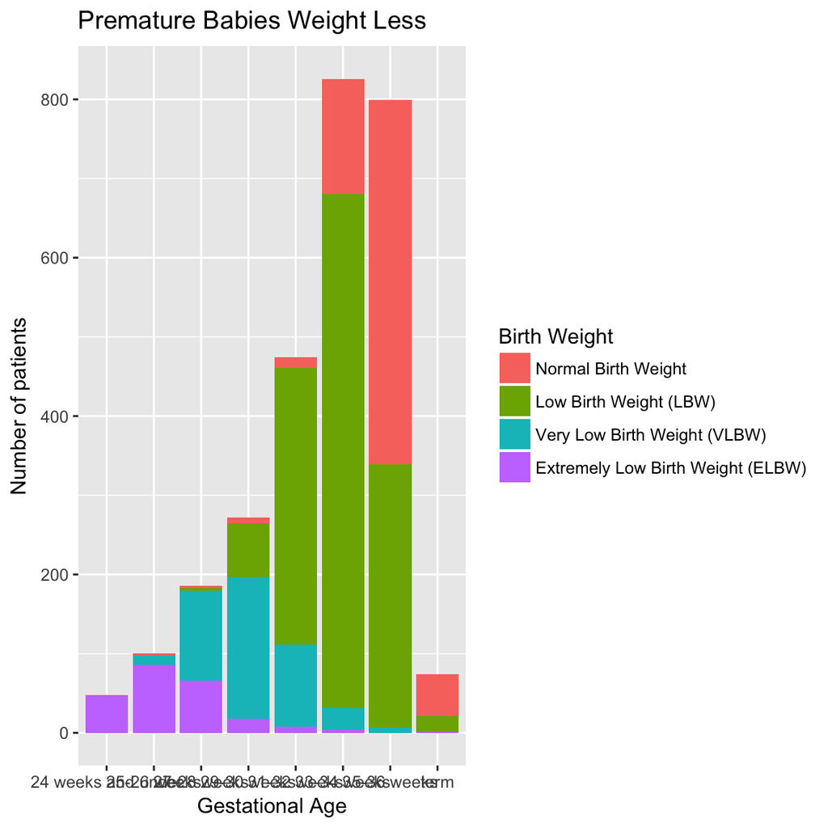

```r
ggplot(data = photo_babies_complete, aes(x = gestational_age_fac, fill = birth_weight_fac)) +
    geom_bar() +
    labs(x = "Gestational Age",
         y = "Number of patients",
         title = "Premature Babies Weight Less") +
  scale_fill_discrete(name = "Birth Weight")
```

So when considering how birth weight plays into ultimate need for phototherapy, I will definitely need to adjust for prematurity as well due to the strength of this relationship.

# 6 Analysis of `m0`

## 6.1 `m0` : a model predicting need for phototherapy based on factors knowable immediately after delivery

```r
dd <- datadist(photo_babies_complete)
options(datadist="dd")

m0 <- lrm(phototherapy ~ birth_weight_fac + gestational_age_fac + ethnicity_fac, data = photo_babies_complete, x=TRUE, y=TRUE)
m0
```

```
Logistic Regression Model

 lrm(formula = phototherapy ~ birth_weight_fac + gestational_age_fac +
     ethnicity_fac, data = photo_babies_complete, x = TRUE, y = TRUE)

                       Model Likelihood     Discrimination    Rank Discrim.
                          Ratio Test           Indexes           Indexes
 Obs          2779    LR chi2     801.87    R2       0.344    C       0.801
  0            990    d.f.            11    g        1.541    Dxy     0.603
  1           1789    Pr(> chi2) <0.0001    gr       4.670    gamma   0.667
 max |deriv| 1e-06                          gp       0.277    tau-a   0.276
                                            Brier    0.168

                                                    Coef    S.E.   Wald Z
 Intercept                                           0.3638 0.6015  0.60
 birth_weight_fac=Low Birth Weight (LBW)             0.2744 0.1133  2.42
 birth_weight_fac=Very Low Birth Weight (VLBW)       1.0618 0.2589  4.10
 birth_weight_fac=Extremely Low Birth Weight (ELBW)  1.4082 0.4544  3.10
 gestational_age_fac=25-26 weeks                     1.0444 0.5924  1.76
 gestational_age_fac=27-28 weeks                     0.8595 0.5687  1.51
 gestational_age_fac=29-30 weeks                     1.5333 0.6194  2.48
 gestational_age_fac=31-32 weeks                     1.2102 0.6044  2.00
 gestational_age_fac=33-34 weeks                    -0.1023 0.5983 -0.17
 gestational_age_fac=35-36 weeks                    -1.2114 0.6008 -2.02
 gestational_age_fac=term                           -1.8902 0.6570 -2.88
 ethnicity_fac=Asian                                 0.7688 0.2059  3.73
                                                    Pr(>|Z|)
 Intercept                                          0.5453
 birth_weight_fac=Low Birth Weight (LBW)            0.0154
 birth_weight_fac=Very Low Birth Weight (VLBW)      <0.0001
 birth_weight_fac=Extremely Low Birth Weight (ELBW) 0.0019
 gestational_age_fac=25-26 weeks                    0.0779
 gestational_age_fac=27-28 weeks                    0.1307
 gestational_age_fac=29-30 weeks                    0.0133
 gestational_age_fac=31-32 weeks                    0.0453
 gestational_age_fac=33-34 weeks                    0.8642
 gestational_age_fac=35-36 weeks                    0.0438
 gestational_age_fac=term                           0.0040
 ethnicity_fac=Asian                                0.0002
```

The first model I fit is one predicting need for phototherapy based on factors that are typically known around the time of delivery - gestational age, ethnicity of infant, and birth weight of infant. Our model here has a C-statistic of 0.80 and R2 0.34.

One note- prior to fitting this model, I considered an interaction between `gestational_age_fac` and `birth_weight_fac` on the basis of a Spearman plot. However, these variables have multiple levels, including some with very few or empty counts (such as a baby born at 24 weeks with normal birth weight, which makes no sense) so I ultimately did not end up going in this direction.

## 6.2 residual plots

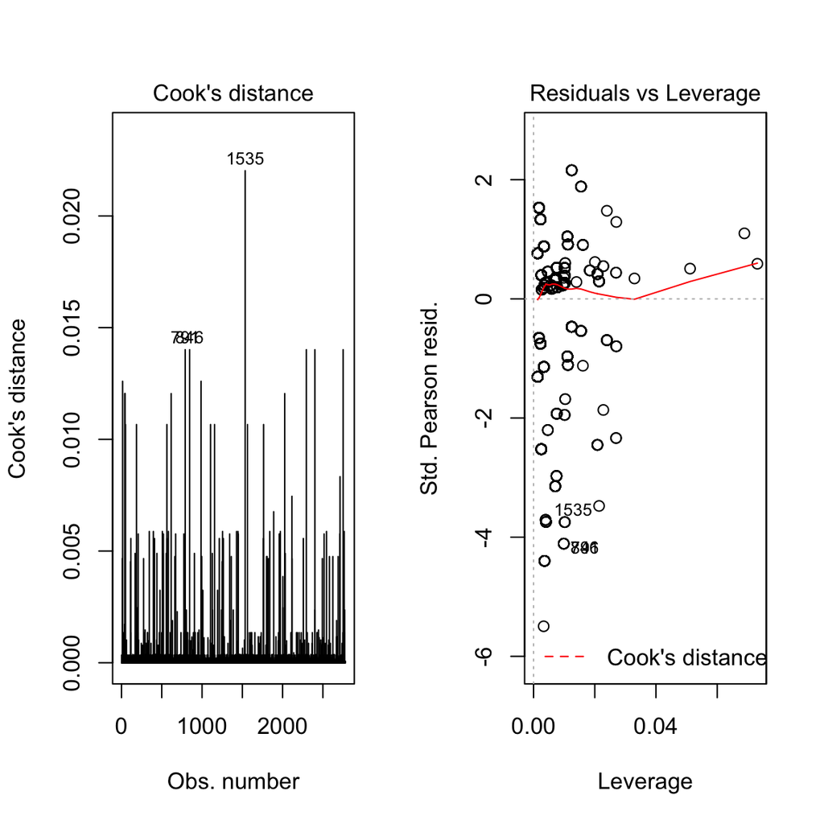

```r
m0glm <- glm(phototherapy ~ birth_weight_fac + gestational_age_fac + ethnicity_fac,
                  data=photo_babies_complete, family="binomial")
par(mfrow=c(1,2))
plot(m0glm, which=c(4:5))
```

Based on these residual plots, there are a few higher leverage points but no particularly influential points to contend with. Overall, I am not concerned for the model based on what I see here.

## 6.3 validate

Next it’s time to validate the model and see how it does.

```r
set.seed(05022018)
validate(m0, B = 100)
```

```
          index.orig training   test optimism index.corrected   n
Dxy           0.6026   0.6039 0.6006   0.0033          0.5993 100
R2            0.3442   0.3476 0.3398   0.0078          0.3364 100
Intercept     0.0000   0.0000 0.0150  -0.0150          0.0150 100
Slope         1.0000   1.0000 0.9834   0.0166          0.9834 100
Emax          0.0000   0.0000 0.0063   0.0063          0.0063 100
D             0.2882   0.2918 0.2839   0.0079          0.2803 100
U            -0.0007  -0.0007 0.0001  -0.0008          0.0001 100
Q             0.2889   0.2925 0.2838   0.0087          0.2802 100
B             0.1683   0.1681 0.1690  -0.0009          0.1693 100
g             1.5412   1.5683 1.5397   0.0286          1.5126 100
gp            0.2773   0.2781 0.2747   0.0034          0.2739 100
```

This **delivery room** model does well in validation, with essentially unchanged C and R2 statistics.

## 6.4 predict

The next step is to make a prediction. My twins were preemies in the NICU, so they will provide a good example to test these models. Both ultimately required phototherapy.

```r
twin_data <- data_frame(subject_id = c("Chris", "Tommy"),
                        sepsis = c(0, 0),
                        birth_weight_fac = c("Low Birth Weight (LBW)", "Low Birth Weight (LBW)"),
                        ABO = c(0, 0),
                        hemolytic = c(0,0),
                        phototherapy = c(1,1),
                        HIE = c(0,0),
                        jaundice = c(1,1),
                        acidosis = c(0, 0),
                        ethnicity_fac = c("Other", "Other"),
                        gestational_age_fac = c("29-30 weeks", "29-30 weeks"))
```

```r
predict(m0, newdata = as.data.frame(twin_data), type= "fitted")
```

```
        1         2
0.8976617 0.8976617
```

Based on this model, at the time of delivery my twins would have a predicted need for phototherapy of 0.90 right off the bat, based solely on their gestational age, birth weight, and ethnicity.

# 7 Analysis of `m1`

## 7.1 `m1`: a model predicting need for phototherapy based on factors typically knowable within the first few days after birth

```r
dd <- datadist(photo_babies_complete)
options(datadist="dd")

m1 <- lrm(phototherapy ~ ABO + birth_weight_fac + gestational_age_fac + ethnicity_fac + hemolytic + HIE + sepsis + acidosis, data = photo_babies_complete, x=TRUE, y=TRUE)
m1
```

```
Logistic Regression Model

 lrm(formula = phototherapy ~ ABO + birth_weight_fac + gestational_age_fac +
     ethnicity_fac + hemolytic + HIE + sepsis + acidosis, data = photo_babies_complete,
     x = TRUE, y = TRUE)

                       Model Likelihood     Discrimination    Rank Discrim.
                          Ratio Test           Indexes           Indexes
 Obs          2779    LR chi2     843.32    R2       0.359    C       0.809
  0            990    d.f.            16    g        1.752    Dxy     0.617
  1           1789    Pr(> chi2) <0.0001    gr       5.767    gamma   0.677
 max |deriv| 0.001                          gp       0.284    tau-a   0.283
                                            Brier    0.166

                                                    Coef    S.E.    Wald Z
 Intercept                                          -0.0669  0.6413 -0.10
 ABO=1                                               0.4301 76.6541  0.01
 birth_weight_fac=Low Birth Weight (LBW)             0.2996  0.1144  2.62
 birth_weight_fac=Very Low Birth Weight (VLBW)       1.0512  0.2632  3.99
 birth_weight_fac=Extremely Low Birth Weight (ELBW)  1.3819  0.4711  2.93
 gestational_age_fac=25-26 weeks                     1.1947  0.6020  1.98
 gestational_age_fac=27-28 weeks                     1.1561  0.5975  1.94
 gestational_age_fac=29-30 weeks                     1.9022  0.6518  2.92
 gestational_age_fac=31-32 weeks                     1.5956  0.6414  2.49
 gestational_age_fac=33-34 weeks                     0.2620  0.6360  0.41
 gestational_age_fac=35-36 weeks                    -0.8237  0.6391 -1.29
 gestational_age_fac=term                           -1.5030  0.6906 -2.18
 ethnicity_fac=Asian                                 0.7559  0.2067  3.66
 hemolytic=1                                         9.7745 33.6555  0.29
 HIE=1                                              -1.4075  0.7236 -1.95
 sepsis=1                                            0.4808  0.2839  1.69
 acidosis=1                                          0.8781  0.3656  2.40
                                                    Pr(>|Z|)
 Intercept                                          0.9169
 ABO=1                                              0.9955
 birth_weight_fac=Low Birth Weight (LBW)            0.0088
 birth_weight_fac=Very Low Birth Weight (VLBW)      <0.0001
 birth_weight_fac=Extremely Low Birth Weight (ELBW) 0.0034
 gestational_age_fac=25-26 weeks                    0.0472
 gestational_age_fac=27-28 weeks                    0.0530
 gestational_age_fac=29-30 weeks                    0.0035
 gestational_age_fac=31-32 weeks                    0.0129
 gestational_age_fac=33-34 weeks                    0.6804
 gestational_age_fac=35-36 weeks                    0.1975
 gestational_age_fac=term                           0.0295
 ethnicity_fac=Asian                                0.0003
 hemolytic=1                                        0.7715
 HIE=1                                              0.0518
 sepsis=1                                           0.0903
 acidosis=1                                         0.0163
```

The above model, called `m1`, is a model predicting need for phototherapy on the basis of birth weight (the main predictor I am studying) in addition to a number of covariates that have been linked to need for phototherapy in the clinical literature and that would typically be available within the first few days of life. The model performs fairly well, with a C statistic of 0.81, and an R2 of 0.36.

In this model I note a few terms that did not reach statistical significance (like `ABO`, `HIE`, `sepsis`, and `hemolytic`). I will leave these in based on the fact that these factors have a known and important clinical relationship to the development of jaundice.

## 7.2 residual plots

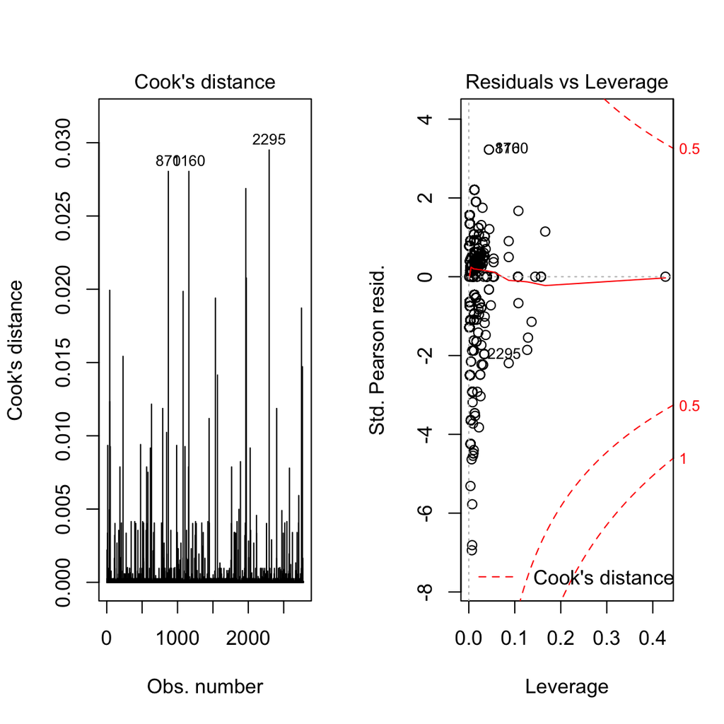

```r
m1glm <- glm(phototherapy ~ ABO + birth_weight_fac + gestational_age_fac + ethnicity_fac + hemolytic + HIE + sepsis + acidosis,
                  data=photo_babies_complete, family="binomial")
par(mfrow=c(1,2))
plot(m1glm, which=c(4:5))
```

As shown above, there is one highly leveraged point, but no points that are significantly influential by way of Cook’s distance.

## 7.3 validate

Next it’s time to validate the model and see how it does.

```r
set.seed(05022018)
validate(m1, B = 100)
```

```
          index.orig training   test optimism index.corrected   n
Dxy           0.6175   0.6213 0.6161   0.0052          0.6122 100
R2            0.3595   0.3647 0.3534   0.0113          0.3482 100
Intercept     0.0000   0.0000 0.0187  -0.0187          0.0187 100
Slope         1.0000   1.0000 0.9741   0.0259          0.9741 100
Emax          0.0000   0.0000 0.0090   0.0090          0.0090 100
D             0.3031   0.3086 0.2971   0.0115          0.2916 100
U            -0.0007  -0.0007 0.0003  -0.0010          0.0003 100
Q             0.3038   0.3093 0.2968   0.0125          0.2914 100
B             0.1656   0.1649 0.1663  -0.0014          0.1670 100
g             1.7522   1.7858 1.7376   0.0483          1.7039 100
gp            0.2838   0.2853 0.2804   0.0049          0.2789 100
```

The validated C statistic stays at 0.81, and the R2 drops minimally to 0.35. So, overall, the model validates pretty well.

## 7.4 predict

```r
predict(m1, newdata = as.data.frame(twin_data), type= "fitted")
```

```
        1         2
0.8942541 0.8942541
```

Based on `m1`, Chris and Tommy both had Pr(phototherapy) = 0.89. This is not significantly different than the probability given by the previous model, `m0`.

# 8 Analysis of `m2`

## 8.1 `m2`: a full model for predicting phototherapy incorporating all elements of the previous models AND clinical diagnosis of jaundice

Finally, I looked at a model that incorporates all the predictors of need for phototherapy seen in the first two models, along with a new term (`jaundice`) representing diagnosis of jaundice.

```r
m2 <- lrm(phototherapy ~ ABO + acidosis + birth_weight_fac + gestational_age_fac + ethnicity_fac + hemolytic + jaundice + HIE + sepsis, data = photo_babies_complete, x = TRUE, y = TRUE)
m2
```

```
Logistic Regression Model

 lrm(formula = phototherapy ~ ABO + acidosis + birth_weight_fac +
     gestational_age_fac + ethnicity_fac + hemolytic + jaundice +
     HIE + sepsis, data = photo_babies_complete, x = TRUE, y = TRUE)

                       Model Likelihood     Discrimination    Rank Discrim.
                          Ratio Test           Indexes           Indexes
 Obs          2779    LR chi2    2196.00    R2       0.750    C       0.940
  0            990    d.f.            17    g        3.607    Dxy     0.879
  1           1789    Pr(> chi2) <0.0001    gr      36.874    gamma   0.904
 max |deriv| 0.002                          gp       0.404    tau-a   0.404
                                            Brier    0.075

                                                    Coef    S.E.    Wald Z
 Intercept                                          -2.8911  1.0408 -2.78
 ABO=1                                               0.7889 64.5452  0.01
 acidosis=1                                          0.5162  0.4967  1.04
 birth_weight_fac=Low Birth Weight (LBW)             0.2339  0.1712  1.37
 birth_weight_fac=Very Low Birth Weight (VLBW)       1.2195  0.4081  2.99
 birth_weight_fac=Extremely Low Birth Weight (ELBW)  1.1282  0.7267  1.55
 gestational_age_fac=25-26 weeks                     1.2032  0.9674  1.24
 gestational_age_fac=27-28 weeks                     0.0595  0.9603  0.06
 gestational_age_fac=29-30 weeks                     0.7843  1.0455  0.75
 gestational_age_fac=31-32 weeks                     0.2997  1.0348  0.29
 gestational_age_fac=33-34 weeks                    -1.2687  1.0318 -1.23
 gestational_age_fac=35-36 weeks                    -1.5649  1.0366 -1.51
 gestational_age_fac=term                           -0.5451  1.1416 -0.48
 ethnicity_fac=Asian                                 1.1819  0.3711  3.18
 hemolytic=1                                        12.7087 28.4491  0.45
 jaundice=1                                          5.3572  0.2427 22.07
 HIE=1                                              -0.0972  0.8989 -0.11
 sepsis=1                                           -0.2357  0.3593 -0.66
                                                    Pr(>|Z|)
 Intercept                                          0.0055
 ABO=1                                              0.9902
 acidosis=1                                         0.2987
 birth_weight_fac=Low Birth Weight (LBW)            0.1719
 birth_weight_fac=Very Low Birth Weight (VLBW)      0.0028
 birth_weight_fac=Extremely Low Birth Weight (ELBW) 0.1205
 gestational_age_fac=25-26 weeks                    0.2136
 gestational_age_fac=27-28 weeks                    0.9506
 gestational_age_fac=29-30 weeks                    0.4531
 gestational_age_fac=31-32 weeks                    0.7721
 gestational_age_fac=33-34 weeks                    0.2189
 gestational_age_fac=35-36 weeks                    0.1311
 gestational_age_fac=term                           0.6330
 ethnicity_fac=Asian                                0.0014
 hemolytic=1                                        0.6551
 jaundice=1                                         <0.0001
 HIE=1                                              0.9139
 sepsis=1                                           0.5118
```

With this model, our C statistic climbs through the roof to 0.94, and the R2 jumps to 0.75. Although it is satisfying to see such high model performance, I am a bit skeptical about these results. The model’s increase in performance is due to the introduction of this new term for diagnosis of jaundice. Could this increase be merely due to an idiosyncrasy in how the NICU at Beth Israel operates? Specifically, do clinicians there normally not bother coding for jaundice until a baby’s jaundice levels reach the threshold for phototherapy?

## 8.2 brief stop: evaluating the relationship between ICD9 coding for jaundice and need for phototherapy in this data set

To answer this question, let’s look briefly at `m3`. I fit this model simply to evaluate the relationship between ICD9 code for jaundice and phototherapy in this particular data set; it turns out that the relationship is strong with a C statistic of 0.87 and R2 of 0.67. So, it must be true that either 1) babies who start to get jaundice in the NICU nearly all progress to treatment levels eventually, or 2) clinicians in this data set coded jaundice largely when the baby was close to treatment levels, or 3) some combination of both.

```r
m3<- lrm(phototherapy ~ jaundice, data = photo_babies_complete)
m3
```

```
Logistic Regression Model

 lrm(formula = phototherapy ~ jaundice, data = photo_babies_complete)

                       Model Likelihood     Discrimination    Rank Discrim.
                          Ratio Test           Indexes           Indexes
 Obs          2779    LR chi2    1865.58    R2       0.672    C       0.871
  0            990    d.f.             1    g        2.023    Dxy     0.743
  1           1789    Pr(> chi2) <0.0001    gr       7.563    gamma   0.986
 max |deriv| 6e-13                          gp       0.341    tau-a   0.341
                                            Brier    0.088

            Coef    S.E.   Wald Z Pr(>|Z|)
 Intercept  -2.9171 0.1603 -18.19 <0.0001
 jaundice=1  4.9366 0.1749  28.22 <0.0001
```

With this context in mind, let’s turn back to analyzing `m2`.

## 8.3 residual plots (`m2`)

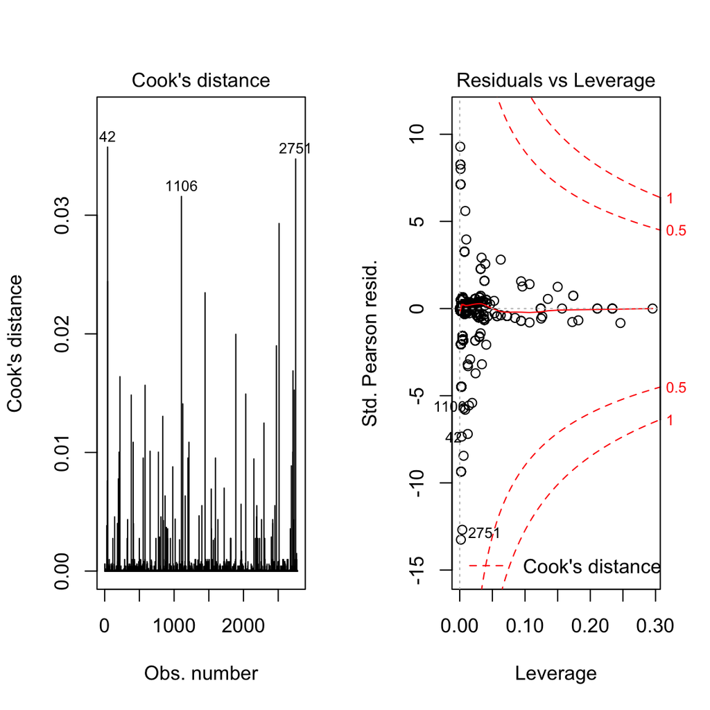

```r
m2glm <- glm(phototherapy ~ ABO + birth_weight_fac + gestational_age_fac + ethnicity_fac + hemolytic + HIE + sepsis + acidosis + jaundice,
                  data=photo_babies_complete, family="binomial")
par(mfrow=c(1,2))
plot(m2glm, which=c(4:5))
```

## 8.4 validate (`m2`)

```r
set.seed(05022018)
validate(m2, B = 100)
```

```
          index.orig training   test optimism index.corrected   n
Dxy           0.8794   0.8811 0.8773   0.0038          0.8757 100
R2            0.7502   0.7526 0.7470   0.0056          0.7447 100
Intercept     0.0000   0.0000 0.0369  -0.0369          0.0369 100
Slope         1.0000   1.0000 0.9768   0.0232          0.9768 100
Emax          0.0000   0.0000 0.0120   0.0120          0.0120 100
D             0.7899   0.7944 0.7848   0.0097          0.7802 100
U            -0.0007  -0.0007 0.0002  -0.0009          0.0002 100
Q             0.7906   0.7951 0.7846   0.0106          0.7800 100
B             0.0752   0.0750 0.0758  -0.0008          0.0760 100
g             3.6075   3.6960 3.6030   0.0930          3.5145 100
gp            0.4039   0.4048 0.4028   0.0021          0.4019 100
```

Our validated C statistic stays at 0.94, and the R2 drops minimally to 0.74. So the model validates quite well.

Although we can definitely anticipate what direction the prediction will go, how would the prediction for Chris and Tommy change in this model?

## 8.5 predict (`m2`)

```r
predict(m2, newdata = as.data.frame(twin_data), type= "fitted")
```

```
        1         2
0.9702371 0.9702371
```

So the boys would have a much even higher prediction for needing phototherapy once diagnosed with jaundice.

# 9 Model Summaries

[output not shown]

In this table, model discrimination increases as we go from less clinical information about a patient (earlier in the hospital course) to more. A major factor in predicting need for phototherapy is simply being diagnosed with jaundice by a clinician.

# 10 Conclusions